# R Markdown: Links between personality, reproductive success and re-pairing patterns in a long-lived seabird

```r
r.squaredGLMM(repro_pers_mod)
```

```
##                    R2m       R2c
## theoretical 0.09090152 0.6475260
## delta       0.08371748 0.5963513
```

We then employ model selection. Three models are retained. The first highlights absolute difference in boldness score, the second highlights female boldness score and the third is the null model.

```r
sur_mol_ab<-dredge(repro_pers_mod, extra = alist(deviance)) # create all possible models
sur_mol_absb<-subset(sur_mol_ab, delta<2) ##subsets models delta <2
nest_repro_pers <- subset(sur_mol_absb, !nested(.)) # remove nested models
repro_pers_coeffs<-coefTable(nest_repro_pers, full=TRUE) # create final coefficient tables
repro_pers_coeffs
```

```
## $`2`
##               Estimate Std. Error  df
## (Intercept)   -0.69535    0.77765 207
## absol_pers_sc -0.34684    0.18480 207
##
## $`5`
##                Estimate Std. Error  df
## (Intercept)    -0.74120    0.78798 207
## female_pers_sc  0.30398    0.20405 207
##
## $`1`
##             Estimate Std. Error  df
## (Intercept) -0.65866    0.77345 208
```

Simplified models (based on the model selection criteria) are built to generate the data needed for visualisation.

```r
repro_pers_mod_ab<- glmer(chick_sur ~ #female_pers_sc+
                         #male_pers_sc+
                         absol+ #changed to original variable so that the graph axis is not scaled i.e positive values only
                         #colony+
                         #absol_pers_sc:colony+
                         (1|year)+
                         (1|pair_ID)+
                         (1|male_ring)+
                         (1|female_ring),
                       data = repro_pers, na.action=na.fail, family = binomial(link = "logit"),
                       control=glmerControl(optimizer="bobyqa",
                                            optCtrl=list(maxfun=2e5)))

repro_pers_mod_fe<- glmer(chick_sur ~ female_pers_sc+ # does not matter is this is scaled
                         #male_pers_sc+
                         #absol_pers_sc+
                         #colony+
                         #absol_pers_sc:colony+
                         (1|year)+
                         (1|pair_ID)+
                         (1|male_ring)+
                         (1|female_ring),
                       data = repro_pers, na.action=na.fail, family = binomial(link = "logit"),
                       control=glmerControl(optimizer="bobyqa",
                                            optCtrl=list(maxfun=2e5)))
```

To create the prediction graphs the relevant data are extracted using sjPlot and used in tandem with the original data to show the trends.

```r
repro_pers$chick_sur_num <- as.numeric(repro_pers$chick_sur) - 1 #creates scale for chick survival probability

pers_chick_sur<-plot_model(repro_pers_mod_ab, type = "pred", terms=c ("absol[all]"))
repro_pers_plot1<-as.data.frame(pers_chick_sur[["data"]]) #data turned into data frame
repro_pers_plot1$absol<-repro_pers_plot1$x # variables are renamed so they can be used in the same graph
repro_pers_plot1$chick_sur<-repro_pers_plot1$predicted

rep_in<-plot_model(repro_pers_mod_fe, type = "pred", terms=c ("female_pers_sc[all]"))
repro_pers_plot2<-as.data.frame(rep_in[["data"]]) #data turned into data frame
repro_pers_plot2$female_pers_sc<-repro_pers_plot2$x # variables are renamed so they can be used in the same graph
repro_pers_plot2$chick_sur<-repro_pers_plot2$predicted
```

The model data and the original data and then combined to make the plots. One plot is made to show the impact of absolute boldness and the other shows the impact of female boldness. These were then combined outside R.

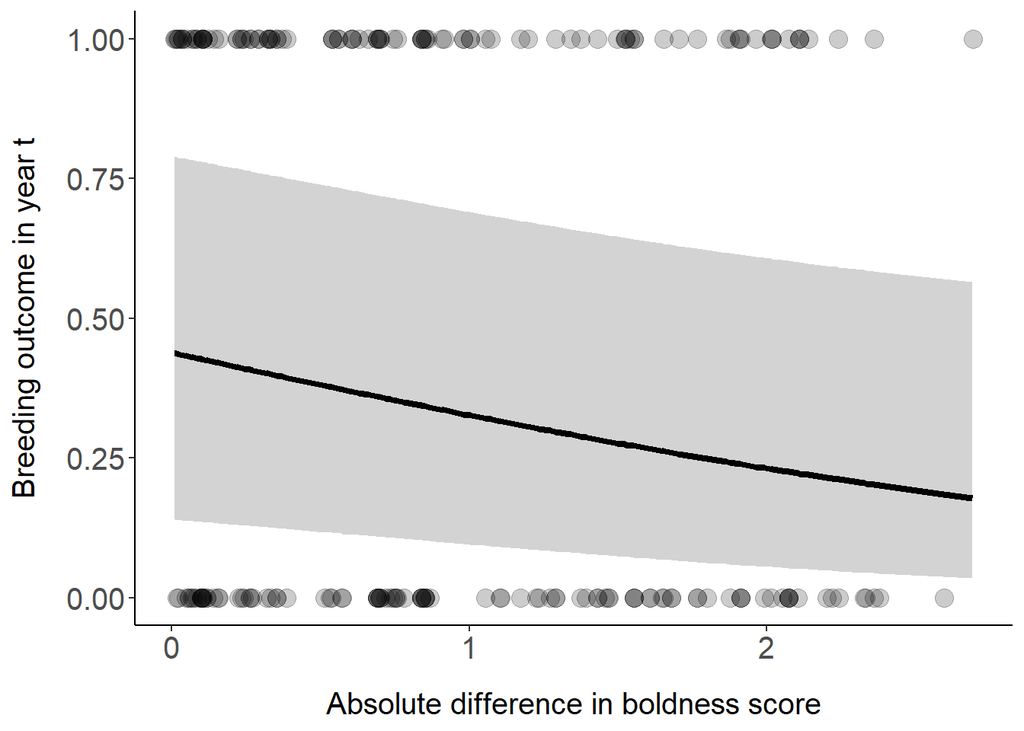

```r
repro_pers_plot1<-ggplot()+ geom_point(data= repro_pers, aes(x = absol, y = chick_sur_num), alpha = 0.2, size = 4)+
  geom_ribbon(data=repro_pers_plot1, aes(x = absol, ymin = conf.low, ymax = conf.high), fill = "lightgrey")+
 geom_line(data=repro_pers_plot1, aes(x = absol, y = chick_sur), linewidth = 1.5)+
 theme_classic()+
 xlab("Absolute difference in boldness score")+
 ylab("Breeding outcome in year t")+
theme(axis.text = element_text(size = 15))+
theme(axis.title= element_text(size=15))+
theme (axis.title.y = element_text (margin = margin (t = 0, r = 13, b = 0, l = 0)))+
theme (axis.title.x = element_text (margin = margin (t = 13, r = 0, b = 0, l = 0)))

repro_pers_plot1
```

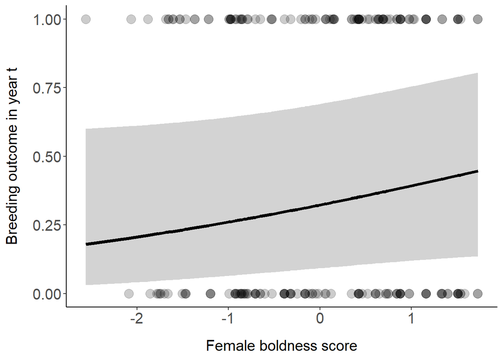

```r
#repro_pers_plot3

repro_pers_plot3<-ggplot()+ geom_point(data= repro_pers, aes(x = female_pers_sc, y = chick_sur_num), alpha = 0.2, size = 4)+
  geom_ribbon(data=repro_pers_plot2, aes(x = female_pers_sc, ymin = conf.low, ymax = conf.high), fill = "lightgrey")+
  geom_line(data=repro_pers_plot2, aes(x = female_pers_sc, y = chick_sur), linewidth = 1.5)+
  theme_classic()+
  xlab("Female boldness score")+
  ylab("Breeding outcome in year t")+
  theme(axis.text = element_text(size = 15))+
  theme(axis.title= element_text(size=15))+
  theme (axis.title.y = element_text (margin = margin (t = 0, r = 13, b = 0, l = 0)))+
  theme (axis.title.x = element_text (margin = margin (t = 13, r = 0, b = 0, l = 0)))

repro_pers_plot3
```

## Model 3: Reproductive outcome and re-pairing probability

In this model the influence of reproductive success in year t on re-pairing likelihood in year t + 1 is evaluated.To begin, the data are filtered so that any missing data from the variables required for this model are removed.

```r
#exclusions
suc_rep<-all_kitt[!is.na(all_kitt$chick_sur),]# remove nests with no breeding success info
suc_rep<-suc_rep[!is.na(suc_rep$season_outcome),] # remove nests with no next season repairing outcome info
```

Exploring the data gives us details of the sample sizes included in the model.

```r
unique(suc_rep$pair_ID)#139 pairs
unique(suc_rep$cycle_pair)#218 breeding attempts

unique(suc_rep$male_ring)#108 male birds
unique(suc_rep$female_ring)#111 female birds

unique(suc_rep$year) #11 breeding seasons
with(suc_rep, tapply(pair_ID, year, FUN = function(x) length(unique(x)))) # sample size per year
```

We then build the global model. Here, `chick_sur` represents the binary breeding outcome for year t. We also generate R squared values for the model.

```r
repro_repair  <- glmer(season_outcome ~ chick_sur+
                         colony+
                         (1|year)+
                         (1|pair_ID)+
                         (1|male_ring)+
                         (1|female_ring),
                       data = suc_rep, na.action=na.fail, family = binomial(link = "logit"),
                       control=glmerControl(optimizer="bobyqa",
                                            optCtrl=list(maxfun=2e5)))
summary(repro_repair)
```

```
## Generalized linear mixed model fit by maximum likelihood (Laplace
##   Approximation) [glmerMod]
##  Family: binomial  ( logit )
## Formula: season_outcome ~ chick_sur + colony + (1 | year) + (1 | pair_ID) +
##     (1 | male_ring) + (1 | female_ring)
##    Data: suc_rep
## Control: glmerControl(optimizer = "bobyqa", optCtrl = list(maxfun = 2e+05))
##
##      AIC      BIC   logLik deviance df.resid
##    272.8    296.4   -129.4    258.8      211
##
## Scaled residuals:
##     Min      1Q  Median      3Q     Max
## -1.1365 -0.5716 -0.4471  0.8315  1.9832
##
## Random effects:
##  Groups      Name        Variance Std.Dev.
##  pair_ID     (Intercept) 0.0000   0.0000
##  female_ring (Intercept) 0.6969   0.8348
##  male_ring   (Intercept) 0.0000   0.0000
##  year        (Intercept) 0.4021   0.6341
## Number of obs: 218, groups:
## pair_ID, 139; female_ring, 111; male_ring, 108; year, 11
##
## Fixed effects:
##                 Estimate Std. Error z value Pr(>|z|)
## (Intercept)      -0.1152     0.3885  -0.297  0.76683
## chick_sur1       -1.1361     0.4341  -2.617  0.00887 **
## colonypyramiden  -0.1745     0.6507  -0.268  0.78854
## ---
## Signif. codes:  0 '***' 0.001 '**' 0.01 '*' 0.05 '.' 0.1 ' ' 1
##
## Correlation of Fixed Effects:
##             (Intr) chck_1
## chick_sur1  -0.552
## colnypyrmdn -0.387 -0.057
## optimizer (bobyqa) convergence code: 0 (OK)
## boundary (singular) fit: see help('isSingular')
```

```r
r.squaredGLMM(repro_repair)
```

```
##                    R2m       R2c
## theoretical 0.07134995 0.3038784
## delta       0.05746076 0.2447245
```

We then employ model selection.

```r
repair_repro<-dredge(repro_repair, extra = alist(deviance)) # create all possible models
rep_repro_sb<-subset(repair_repro, delta<2) ##subsets models delta <2
repair_repro_coeffs<-coefTable(rep_repro_sb, full=TRUE) # final coefficient table
repair_repro_coeffs
```

```
## $`2`
##             Estimate Std. Error  df
## (Intercept) -0.15332    0.35910 212
## chick_sur1  -1.14650    0.43176 212
```

The best fitting model retains only chick survival as an influence on re-pairing probability.

We build a simplified model which reflect the results of our model selection criteria.This will be used for visualisation.

```r
repro_repair_g  <- glmer(season_outcome ~ chick_sur+
                         (1|year)+
                         (1|pair_ID)+
                         (1|male_ring)+
                         (1|female_ring),
                       data = suc_rep, na.action=na.fail, family = binomial(link = "logit"),
                       control=glmerControl(optimizer="bobyqa",
                                            optCtrl=list(maxfun=2e5)))
```

We use sjPlot to extract the data used in the graph.

```r
rep_repair_chick_sur<-plot_model(repro_repair, type = "pred", terms=c ("chick_sur"))
repro_plot2<-as.data.frame(rep_repair_chick_sur[["data"]])
repro_plot2$season_outcome2<-repro_plot2$predicted # variables are renamed so they can be used in the same graph
```

variables are renamed to make the final graph clearer.A new scale is created for the response variable so it is clear on the final graph.

```r
for (a in 1:(nrow(repro_plot2))){

  if (repro_plot2$x[a] == "0")

  {repro_plot2$chick_sur2[a]<-"Failure"}
  else {repro_plot2$chick_sur2[a]<-"Success"}
}

for (a in 1:(nrow(suc_rep))){

  if (suc_rep$chick_sur[a] == "0")

  {suc_rep$chick_sur2[a]<-"Failure"}
  else {suc_rep$chick_sur2[a]<-"Success"}
}

#new scale created for season outcome to make graph more logical
suc_rep$season_outcome2<- as.numeric(suc_rep$season_outcome) - 1
```

The final graph is produced.

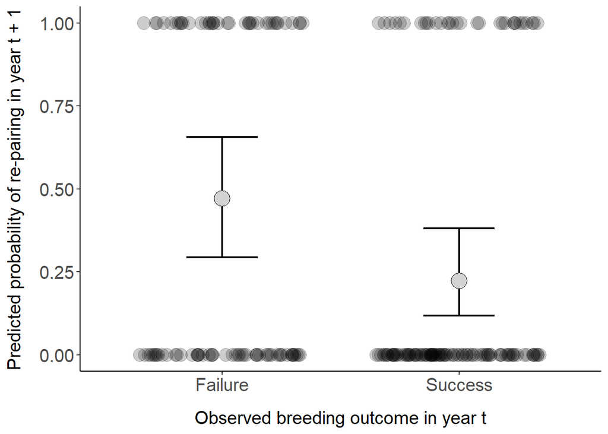

```r
repro_plotg2<-ggplot()+
  geom_jitter(data = suc_rep, aes(x =chick_sur2, y = season_outcome2), width =0.35, height = 0.0, alpha = 0.2, size = 5)+
  geom_errorbar(data= repro_plot2, aes(x = chick_sur2, ymin = conf.low, ymax = conf.high), width = 0.3, linewidth = 0.8)+
  geom_point(data = repro_plot2, aes( x = chick_sur2, y = season_outcome2), colour ="black", fill = "lightgrey", pch=21, size = 6)+
  theme_classic()+
  xlab("Observed breeding outcome in year t")+
  ylab("Predicted probability of re-pairing in year t + 1")+
  theme(axis.text = element_text(size = 15))+
  theme(axis.title= element_text(size=15))+
  theme (axis.title.y = element_text (margin = margin (t = 0, r = 13, b = 0, l = 0)))+
  theme (axis.title.x = element_text (margin = margin (t = 13, r = 0, b = 0, l = 0)))

repro_plotg2
```

## Model 4: Re-pairing and future reproductive outcomes

In this model the influence of re-pairing outcome on reproductive success in year t + 1 is evaluated.To begin, the data are filtered so that any missing data from the variables required for this model are removed. the categorical variables are turned into factors.

```r
ns_repro<-next_season_repro[!is.na(next_season_repro$season_outcome),]
ns_repro<-ns_repro[!is.na(ns_repro$next_season),]

ns_repro$colony<-as.factor(ns_repro$colony)
ns_repro$sex<-as.factor(ns_repro$sex)
ns_repro$ring<-as.factor(ns_repro$ring)
ns_repro$pair_ID<-as.factor(ns_repro$pair_ID)
ns_repro$year_t<-as.factor(ns_repro$year_t)
ns_repro$season_outcome<-as.factor(ns_repro$season_outcome)
ns_repro$next_season<-as.factor(ns_repro$next_season)
ns_repro$season_tru<-as.factor(ns_repro$season_tru)
ns_repro$cycle_pair<-as.factor(ns_repro$cycle_pair)
```

The sample sizes may be determined using the below code.

```r
unique(ns_repro$cycle_pair) #175 breeding attempts
unique(ns_repro$pair_ID) # 107 pairs
with(ns_repro, tapply(cycle_pair, year_t, FUN = function(x) length(unique(x)))) # sample per year
with(ns_repro, tapply(ring, sex, FUN = function(x) length(unique(x)))) # 75 females, 70 males
```

The global model 4 is built. In the this model `next_season` is the breeding success in year t + 1 and `season_outcome` is the re-pairing outcome at the start of year t + 1.

```r
next_season_mol  <- glmer(next_season ~ colony+
                            season_outcome+
                            season_outcome:sex+
                            sex+
                            (1|year_t)+
                            (1|pair_ID)+
                            (1|ring),
                          data = ns_repro,na.action=na.fail, family = binomial(link = "logit"),
                          control=glmerControl(optimizer="bobyqa",
                                               optCtrl=list(maxfun=2e5)))
summary(next_season_mol)
```

```
## Generalized linear mixed model fit by maximum likelihood (Laplace
##   Approximation) [glmerMod]
##  Family: binomial  ( logit )
## Formula: next_season ~ colony + season_outcome + season_outcome:sex +
##     sex + (1 | year_t) + (1 | pair_ID) + (1 | ring)
##    Data: ns_repro
## Control: glmerControl(optimizer = "bobyqa", optCtrl = list(maxfun = 2e+05))
##
##      AIC      BIC   logLik deviance df.resid
##    240.6    270.4   -112.3    224.6      296
##
## Scaled residuals:
##      Min       1Q   Median       3Q      Max
## -2.71578 -0.02215 -0.00389  0.22051  2.49521
##
## Random effects:
##  Groups  Name        Variance  Std.Dev.
##  ring    (Intercept) 2.552e-16 1.597e-08
##  pair_ID (Intercept) 1.209e+01 3.477e+00
##  year_t  (Intercept) 1.477e+02 1.215e+01
## Number of obs: 304, groups:  ring, 145; pair_ID, 107; year_t, 10
##
## Fixed effects:
##                        Estimate Std. Error z value Pr(>|z|)
## (Intercept)          -9.339e+00  4.192e+00  -2.228   0.0259 *
## colonypyramiden       8.204e+00  1.286e+01   0.638   0.5236
## season_outcome1      -1.439e+00  1.591e+00  -0.904   0.3658
## sexM                 -2.009e-07  5.297e-01   0.000   1.0000
## season_outcome1:sexM  1.015e+00  1.816e+00   0.559   0.5761
## ---
## Signif. codes:  0 '***' 0.001 '**' 0.01 '*' 0.05 '.' 0.1 ' ' 1
##
## Correlation of Fixed Effects:
##             (Intr) clnypy ssn_t1 sexM
## colnypyrmdn -0.319
## season_tcm1  0.064 -0.028
## sexM        -0.063  0.000  0.166
## ssn_tcm1:sM -0.057  0.020 -0.734 -0.292
## optimizer (bobyqa) convergence code: 0 (OK)
## boundary (singular) fit: see help('isSingular')
```

```r
r.squaredGLMM(next_season_mol)
```

```
##                      R2m          R2c
## theoretical 6.500283e-02 9.811348e-01
## delta       3.175692e-06 4.793301e-05
```

Model selection takes place as before.

```r
next_season_dre<-dredge(next_season_mol, extra = alist(deviance))
next_season_dre2<-subset(next_season_dre, delta<2) ##subsets models delta <2
next_season_dre3<- subset(next_season_dre2, !nested(.))# remove nested models
next_season_dre_coeff<-coefTable(next_season_dre3, full=TRUE)
next_season_dre_coeff
```

```
## $`1`
##             Estimate Std. Error  df
## (Intercept)  -3.7944     3.2986 300
```

## Model 5: Boldness and re-pairing probability

In this model the influence of pair members’ boldness and absolute difference in boldness within pairs on re-pairing probability is evaluated. To begin, the data are filtered so that any missing data from the variables required for this model are removed.Model 5 is independent of breeding success in year t and thus the variable `ulti_outcome` can be used (i.e. did the pair dissolve at any point in the data collection period? Y/N). The `missed_seasons` variable accounts for the extra opportunities these birds had to re-pair in between sightings (see paper). Boldness metrics are defined as before.

```r
pers_repair<-all_kitt[!is.na(all_kitt$ulti_outcome),]# where ultimate outcome of the pair is unknown- exclude
pers_repair<-pers_repair[!is.na(pers_repair$absol),]# exclude pairs where both personalities are not available

#scaling

pers_repair$male_pers_sc<-scale(pers_repair$male_pers)
pers_repair$female_pers_sc<-scale(pers_repair$female_pers)
pers_repair$absol_pers_sc<-scale(pers_repair$absol)
```

Descriptive reveal similar patterns to those reported under Model 2.males are bolder than females and birds are bolder at Grumant than Pyramiden.

```r
pers_repair%>%summarise(average=mean(male_pers),med=median(male_pers), #males slightly bolder than females overall
                        sd=sd(male_pers))
```

```
##    average      med        sd
## 1 0.980684 1.217355 0.8817706
```

```r
pers_repair%>%summarise(average=mean(female_pers),med=median(female_pers),
                        sd=sd(female_pers))
```

```
##     average       med        sd
## 1 0.8573766 0.9132636 0.9095447
```

```r
pers_repair%>%group_by(colony)%>%summarise(average=mean(male_pers),med=median(male_pers), #both males and females bolder at grumant
                                           sd=sd(male_pers))
```

```
## # A tibble: 2 × 4
##   colony    average   med    sd
##   <fct>       <dbl> <dbl> <dbl>
## 1 grumant     1.57  1.82  0.633
## 2 pyramiden   0.619 0.870 0.816
```

```r
pers_repair%>%group_by(colony)%>%summarise(average=mean(female_pers),med=median(female_pers),
                                           sd=sd(female_pers))
```

```
## # A tibble: 2 × 4
##   colony    average   med    sd
##   <fct>       <dbl> <dbl> <dbl>
## 1 grumant     1.30  1.66  0.887
## 2 pyramiden   0.586 0.722 0.815
```

Sample sizes can be determined using the below code.

```r
#sample sizes

unique(pers_repair$pair_ID)#98 pairs
unique(pers_repair$cycle_pair)#166 breeding attempts

unique(pers_repair$male_ring)#81 male birds
unique(pers_repair$female_ring)#87 female birds

unique(pers_repair$year) #11 breeding seasons
with(pers_repair, tapply(pair_ID, year, FUN = function(x) length(unique(x))))# sample size per year
with(pers_repair, tapply(pair_ID, colony, FUN = function(x) length(unique(x))))# sample size per colony
```

We test for colinearity between continuous variables. And VIF scores > 5 are problematic. There are no problems highlighted here.

```r
#assumption multicolinearity

colin_model11 <- glm(ulti_outcome ~ male_pers_sc +female_pers_sc, data = pers_repair, family = "binomial")
summary(colin_model11)
```

```
##
## Call:
## glm(formula = ulti_outcome ~ male_pers_sc + female_pers_sc, family = "binomial",
##     data = pers_repair)
##
## Deviance Residuals:
##     Min       1Q   Median       3Q      Max
## -1.0321  -0.8007  -0.7209   1.3394   1.8515
##
## Coefficients:
##                 Estimate Std. Error z value Pr(>|z|)
## (Intercept)    -1.043802   0.179538  -5.814 6.11e-09 ***
## male_pers_sc   -0.324950   0.175280  -1.854   0.0638 .
## female_pers_sc -0.008388   0.182204  -0.046   0.9633
## ---
## Signif. codes:  0 '***' 0.001 '**' 0.01 '*' 0.05 '.' 0.1 ' ' 1
##
## (Dispersion parameter for binomial family taken to be 1)
##
##     Null deviance: 191.99  on 165  degrees of freedom
## Residual deviance: 188.47  on 163  degrees of freedom
## AIC: 194.47
##
## Number of Fisher Scoring iterations: 4
```

```r
vif(colin_model11)
```

```
##   male_pers_sc female_pers_sc
##        1.01514        1.01514
```

```r
colin_model22 <- glm(ulti_outcome ~ male_pers_sc +absol_pers_sc, data = pers_repair, family = "binomial")
summary(colin_model22)
```

```
##
## Call:
## glm(formula = ulti_outcome ~ male_pers_sc + absol_pers_sc, family = "binomial",
##     data = pers_repair)
##
## Deviance Residuals:
##     Min       1Q   Median       3Q      Max
## -1.0591  -0.7817  -0.7210   1.3004   1.8678
##
## Coefficients:
##               Estimate Std. Error z value Pr(>|z|)
## (Intercept)   -1.04439    0.17962  -5.815 6.08e-09 ***
## male_pers_sc  -0.31331    0.17668  -1.773   0.0762 .
## absol_pers_sc  0.06792    0.18065   0.376   0.7069
## ---
## Signif. codes:  0 '***' 0.001 '**' 0.01 '*' 0.05 '.' 0.1 ' ' 1
##
## (Dispersion parameter for binomial family taken to be 1)
##
##     Null deviance: 191.99  on 165  degrees of freedom
## Residual deviance: 188.33  on 163  degrees of freedom
## AIC: 194.33
##
## Number of Fisher Scoring iterations: 4
```

```r
vif(colin_model22)
```

```
##  male_pers_sc absol_pers_sc
##      1.035276      1.035276
```

```r
colin_model33 <- glm(ulti_outcome ~ female_pers_sc +absol_pers_sc, data = pers_repair, family = "binomial")
summary(colin_model33)
```

```
##
## Call:
## glm(formula = ulti_outcome ~ female_pers_sc + absol_pers_sc,
##     family = "binomial", data = pers_repair)
##
## Deviance Residuals:
##     Min       1Q   Median       3Q      Max
## -0.8622  -0.7986  -0.7502   1.5262   1.7040
##
## Coefficients:
##                Estimate Std. Error z value Pr(>|z|)
## (Intercept)    -1.02337    0.17640  -5.801 6.58e-09 ***
## female_pers_sc -0.00545    0.18920  -0.029    0.977
## absol_pers_sc   0.12134    0.18889   0.642    0.521
## ---
## Signif. codes:  0 '***' 0.001 '**' 0.01 '*' 0.05 '.' 0.1 ' ' 1
##
## (Dispersion parameter for binomial family taken to be 1)
##
##     Null deviance: 191.99  on 165  degrees of freedom
## Residual deviance: 191.49  on 163  degrees of freedom
## AIC: 197.49
##
## Number of Fisher Scoring iterations: 4
```

```r
vif(colin_model33)
```

```
## female_pers_sc  absol_pers_sc
##        1.16543        1.16543
```

The global model 5 is built.

```r
repair_mol_abs  <- glmer(ulti_outcome ~ female_pers_sc+
                           male_pers_sc+
                           absol_pers_sc+
                           colony+
                           missed_seasons+ # to account for pairs which had multiple opportunities to re-pair without being recorded
                           (1|year)+
                           (1|pair_ID)+
                           (1|male_ring)+
                           (1|female_ring),
                         data = pers_repair,na.action=na.fail, family = binomial(link = "logit"),
                         control=glmerControl(optimizer="bobyqa",
                                              optCtrl=list(maxfun=2e5)))

summary(repair_mol_abs)
```

```
## Generalized linear mixed model fit by maximum likelihood (Laplace
##   Approximation) [glmerMod]
##  Family: binomial  ( logit )
## Formula: ulti_outcome ~ female_pers_sc + male_pers_sc + absol_pers_sc +
##     colony + missed_seasons + (1 | year) + (1 | pair_ID) + (1 |
##     male_ring) + (1 | female_ring)
##    Data: pers_repair
## Control: glmerControl(optimizer = "bobyqa", optCtrl = list(maxfun = 2e+05))
##
##      AIC      BIC   logLik deviance df.resid
##    194.8    225.9    -87.4    174.8      156
##
## Scaled residuals:
##     Min      1Q  Median      3Q     Max
## -1.1849 -0.5330 -0.3686  0.5186  2.5758
##
## Random effects:
##  Groups      Name        Variance Std.Dev.
##  pair_ID     (Intercept) 0.01039  0.1019
##  female_ring (Intercept) 0.77634  0.8811
##  male_ring   (Intercept) 0.00000  0.0000
##  year        (Intercept) 0.21665  0.4655
## Number of obs: 166, groups:
## pair_ID, 98; female_ring, 87; male_ring, 81; year, 11
##
## Fixed effects:
##                 Estimate Std. Error z value Pr(>|z|)
## (Intercept)     -2.20626    0.59940  -3.681 0.000233 ***
## female_pers_sc   0.26074    0.27637   0.943 0.345446
## male_pers_sc    -0.08076    0.26370  -0.306 0.759405
## absol_pers_sc    0.14422    0.25155   0.573 0.566412
## colonypyramiden  0.94049    0.73307   1.283 0.199511
## missed_seasons   0.88243    0.44094   2.001 0.045364 *
## ---
## Signif. codes:  0 '***' 0.001 '**' 0.01 '*' 0.05 '.' 0.1 ' ' 1
##
## Correlation of Fixed Effects:
##             (Intr) fml_p_ ml_pr_ absl__ clnypy
## feml_prs_sc -0.290
## male_prs_sc -0.237  0.185
## absl_prs_sc -0.108  0.376  0.257
## colnypyrmdn -0.742  0.311  0.371  0.111
## missed_ssns -0.261  0.122 -0.017  0.101 -0.145
## optimizer (bobyqa) convergence code: 0 (OK)
## boundary (singular) fit: see help('isSingular')
```

```r
r.squaredGLMM(repair_mol_abs)
```

```
##                    R2m       R2c
## theoretical 0.13540832 0.3374718
## delta       0.09336083 0.2326789
```

## Permutation tests

These permutation tests assess if re-pairing birds choose a new partner which is more similar to themselves compared to their old partner. First, to determine the observed or ‘true’ difference in boldness scores between new partnerships and original partnerships, the absolute difference in boldness within each new partnership was subtracted from the absolute difference in boldness within the original partnership. A positive value indicated that the new partner was more similar in boldness to the focal bird than its original partner.

```r
absol_ran$trueDiff <- absol_ran$orig_absol - absol_ran$new_absol
```

The colonies are divided to account for the different personality distributions of potential mates at the two sites.

```r
#colonies separately
absol_ran_g<-subset(absol_ran, colony.x == "grumant")
absol_ran_p<-subset(absol_ran, colony.x == "pyramiden")

pers_colony_g<-subset(pers_colony, colony == "Grumant")
pers_colony_p<-subset(pers_colony, colony == "Pyramiden")
```

The loop parameters are set. This includes setting the number of permutations, creating new vectors and calculating the mean true difference.

```r
#randomise personality of new partner across the whole population
## sampling randomly from the true personality distribution

# grumant
n_perms <- 10000 # typical minimum for randomisation/permutation
perms_output <- list()
mean_trueDiff <- mean(absol_ran_g$trueDiff) # this is the observed mean difference
pers_cg<-pers_colony_g$pers_scores
```

The loop is built. Boldness differences are calculated within randomised pairings. Within each permutation, every focal bird in the population was paired with a new partner boldness score, which is randomly sampled from the distribution of boldness scores available within each population. The absolute difference between the focal birds’ boldness and the randomly sampled personalities is calculated and subtracted from the original within pair difference in boldness. This value (within original pair difference – within random pair difference) is then averaged across the population to give a randomised mean difference (difference between the original and randomised pair’s absolute difference). This process is repeated 10,000 times per colony.

```r
for (i in 1:n_perms ) {

  # Randomise new partner personalities
  perm_dat <- data.frame(F_pers = absol_ran_g$F_pers,
                         orig_absol = absol_ran_g$orig_absol,
                         shuffled_part_pers = sample(pers_cg, nrow(absol_ran_g)))

  # Calculate differences
  perm_dat$shuffled_absol <- abs(perm_dat$F_pers - perm_dat$shuffled_part_pers)
  perm_dat$shuffled_orig_diff <- perm_dat$orig_absol - perm_dat$shuffled_absol
  perms_output[[i]] <- mean(perm_dat$shuffled_orig_diff)

}
```

By calculating the proportion of cases where randomised personality values are equal or closer to focal birds’ personality than true partners’ personality (i.e. the null hypothesis)

```r
# Null hypothesis: randomised personality values are equal or closer to focal birds'
# personality than true partners' personality

# Calculate proportion of cases that meet the null hypothesis
length(perms_output[perms_output >= mean_trueDiff])/length(perms_output) # less than #0.05
```

```
## [1] 0.0324
```

```r
# Because we're using simulated data exact results will vary, but if p < 0.05,
# we can infer that focal birds are ending up with partners who are closer to their
# personality than the previous partner than we would expect by chance
```

These results can then be visualised and edited outside r for clarity.

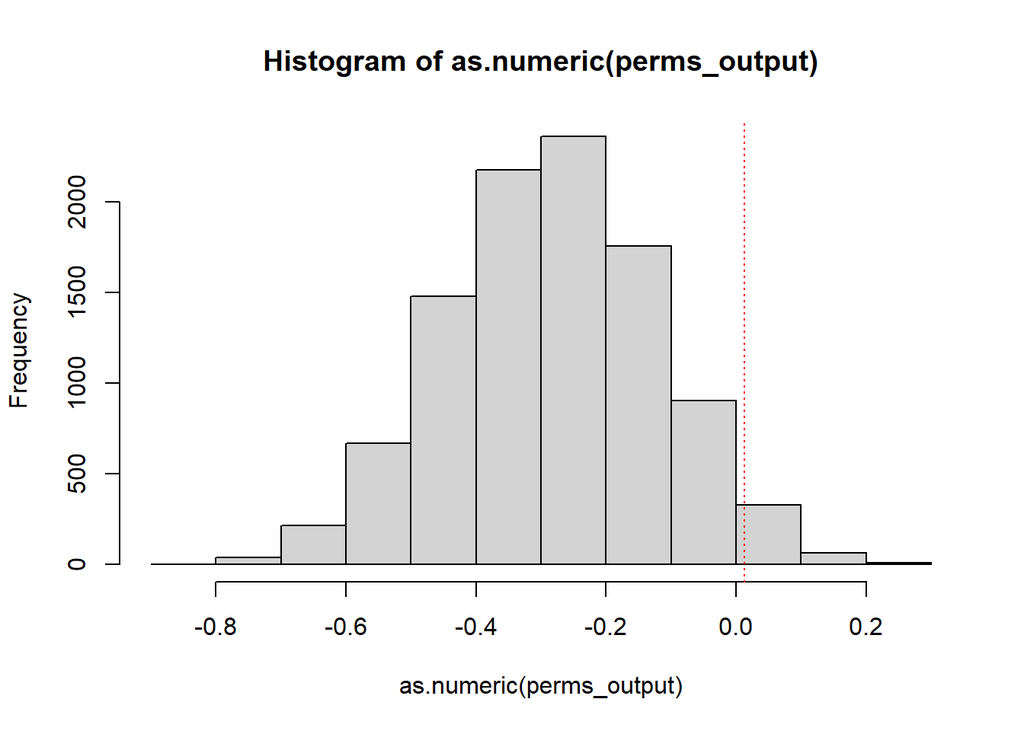

```r
# visualise data
hist(as.numeric(perms_output)) # lots of negative differences = original partner is closer to Focal than randomised
abline(v = mean_trueDiff, col = "red", lty = "dotted")
```

This result suggests that birds at Grumant did not re-pair at random, but instead appeared to choose new partners which were statistically more similar to themselves in boldness than their original partners.

This process is then repeated using data for the Pyramiden birds.

```r
#pyramiden
n_perms <- 10000 # typical minimum for randomisation/permutation
perms_output <- list()
mean_trueDiff <- mean(absol_ran_p$trueDiff) # this is your observed mean difference
pers_cp<-pers_colony_p$pers_scores

for (i in 1:n_perms ) {

  # Randomise new partner personalities
  perm_dat <- data.frame(F_pers = absol_ran_p$F_pers,
                         orig_absol = absol_ran_p$orig_absol,
                         shuffled_part_pers = sample(pers_cp, nrow(absol_ran_p)))
  # x is the simulated personality distribution - you should sample
  # from the real personality distribution.

  # Calculate differences
  perm_dat$shuffled_absol <- abs(perm_dat$F_pers - perm_dat$shuffled_part_pers)
  perm_dat$shuffled_orig_diff <- perm_dat$orig_absol - perm_dat$shuffled_absol
  perms_output[[i]] <- mean(perm_dat$shuffled_orig_diff)

}

# Null hypothesis: randomised personality values are equal or closer to focal birds'
# personality than true partners' personality

# Calculate proportion of cases that meet the null hypothesis
length(perms_output[perms_output >= mean_trueDiff])/length(perms_output) # greater than 0.05
```

```
## [1] 0.4307
```

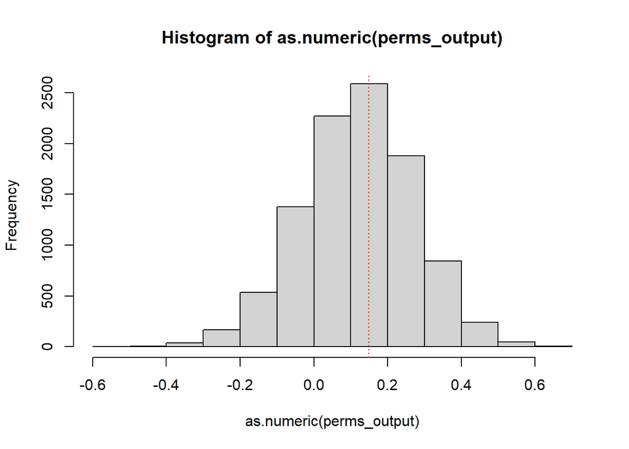

```r
# visualise data
hist(as.numeric(perms_output)) # lots of negative differences = original partner is closer to Focal than randomised
abline(v = mean_trueDiff, col = "red", lty = "dotted")
```

This result suggests that birds at Pyramiden may have re-paired at random.